# Notebook

## CSE 546: Reinforcement Learning

### Prof. Alina Vereshchaka

Welcome to the Assignment 2, Part 1: Introduction to Deep Reinforcement Learning and Neural Networks! The goal of this assignment is to make you comfortable with the application of different Neural Network structures depending on how the Reinforcement Learning environment is set up.

We will be working with an implementation of the Wumpus World environment. The environment comes from the book "Artificial Intelligence: A Modern Approach" by Stuart J. Russell and Peter Norvig.

### ENVIRONMENT DETAILS:

The environment is a 6 x 6 grid world containing a total of 36 grid blocks.

#### ENVIRONMENT OBJECTS:

The environment consists of the following objects:

1. **Agent** - The agent starts in the grid block at the bottom left corner whose co-ordinates are [0, 0]. The goal of our agent is to collect the Gold while avoiding the Wumpus and the pits.
2. **Wumpus** - The monster which would eat the agent if they are in the same grid block.
3. **Pit** - The agent must avoid falling into the pits.
4. **Gold** - The agent must collect the Gold.
5. **Breeze** - Breeze surrounds the Pits and warn the agent of a Pit in an adjacent grid block.
6. **Stench** - Stench surrounds the Wumpus and warns the agent of the Wumpus in an adjacent grid block.

#### ENVIRONMENT OBSERVATIONS:

Our implementation of the environment provides you with four different types of observations:

1. **Integer** - Integer in the range [0 - 35]. This represents the grid block the agent is in. E.g., if the agent is in the bottom left grid block (starting position) the observation would be 0, if the agent is in the grid block containing the Gold the observation would be 34, if the agent is in the top right grid block the observation would be 35.
2. **Vector** -

   **2.1.** A vector of length 2 representing the agent co-ordinates. The first entry represents the x co-ordinate and the second entry represets the y co-ordinate. E.g., if the agent is in the bottom left grid block (starting position) the observation would be [0, 0], if the agent is in the grid block containing the Gold the observation would be [4, 5], if the agent is in the top right grid block the observation would be [5, 5].

   **2.2.** A vector of length 36 representing the one-hot encoding of the integer observation (refer type 1 above). E.g., if the agent is in the bottom left grid block (starting position) the observation would be [1, 0, ..., 0, 0], if the agent is in the grid block containing the Gold the observation would be [0, 0, ..., 1, 0], if the agent is in the top right grid block the observation would be [0, 0, ..., 0, 1].
3. **Image** - Image render of the environment returned as an NumPy array. The image size is 84 * 84 (same size used in the DQN paper). E.g., if the agent is in the bottom right grid block the observation is:

   Observation: (84 * 84)

   [[255 255 255 ... 255 255 255]

   [255 255 255 ... 255 255 255]

   [255 255 255 ... 255 255 255]

   ...

   [255 255 255 ... 255 255 255]

   [255 255 255 ... 255 255 255]

   [255 255 255 ... 255 255 255]]

   Observation type: <class 'numpy.ndarray'>

   Observation Shape: (84, 84)

   Visually, it looks like:

[figure not shown]

4. **Float** - Float in the range [0 - $\infty$] representing the time elapsed in seconds.

#### ENVIRONMENT ACTIONS:

Our implementation of the environment provides you with three different types of actions:

1. **Discrete** - Integer in the range [0 - 3] representing the four actions possible in the environment as follows: 0 - Right 1 - Left 2 - Up 3 - Down.
2. **Multi-Discrete** - Array of length four where each element takes binary values 0 or 1. Array elements represent if we take a particular action. Array element with index 0 corresponds to the right action, index 1 corresponds to the left action, index 2 corresponds to the up action, and index 3 corresponds to the down action. E.g., action = [1, 0, 0, 0] would result in the agent moving right. action = [1, 0, 1, 0] would result in the agent moving right and up. action = [0, 1, 0, 1] would result in the agent moving left and down.
3. **Continuous** - Float in the range [-1, 1] determining whether the agent will go left, right, up, or down as follows:

   if -1 <= action <= -0.5: Go Right. elif -0.5 < action <= 0: Go Left. elif 0 < action <= 0.5: Go Up. elif 0.5 < action <= 1: Go Down.

### YOUR TASK IS TO USE A NEURAL NETWORK TO WORK WITH ALL FOUR TYPES OF OBSERVATIONS AND ALL THREE TYPES OF ACTIONS.

### Note: You don't have to train your agent/neural network. You just have to build the neural network structure that takes the observation as input and produces the desired output with the initial weights.

#### You can use libraries such as PyTorch/TensorFlow/Keras to build your neural networks.

#### You cannot use RL libraries that already provide the neural network to you such as Stable-baselines3, Keras-RL, TF agents, Ray RLLib etc.

```python
# Imports
from environment import WumpusWorldEnvironment
import torch
import torch.nn as nn
import torch.optim as optim
import torch.nn.functional as F
import numpy as np
import random
```

# START COMPLETING YOUR ASSIGNMENT HERE

```
Starting Q-learning training...
Episode 1/1000, Reward: -105, Epsilon: 1.0000
Episode 2/1000, Reward: -104, Epsilon: 0.9950
Episode 3/1000, Reward: -102, Epsilon: 0.9900
Episode 4/1000, Reward: -125, Epsilon: 0.9851
Episode 5/1000, Reward: -109, Epsilon: 0.9801
Episode 6/1000, Reward: -135, Epsilon: 0.9752
Episode 7/1000, Reward: -104, Epsilon: 0.9704
Episode 8/1000, Reward: -103, Epsilon: 0.9655
Episode 9/1000, Reward: -106, Epsilon: 0.9607
Episode 10/1000, Reward: -104, Epsilon: 0.9559
Episode 11/1000, Reward: -106, Epsilon: 0.9511
Episode 12/1000, Reward: -117, Epsilon: 0.9464
Episode 13/1000, Reward: -113, Epsilon: 0.9416
Episode 14/1000, Reward: -102, Epsilon: 0.9369
Episode 15/1000, Reward: -126, Epsilon: 0.9322
Episode 16/1000, Reward: -113, Epsilon: 0.9276
Episode 17/1000, Reward: -111, Epsilon: 0.9229
Episode 18/1000, Reward: -124, Epsilon: 0.9183
Episode 19/1000, Reward: -108, Epsilon: 0.9137
Episode 20/1000, Reward: -101, Epsilon: 0.9092
Episode 21/1000, Reward: -129, Epsilon: 0.9046
Episode 22/1000, Reward: -112, Epsilon: 0.9001
Episode 23/1000, Reward: -109, Epsilon: 0.8956
Episode 24/1000, Reward: -132, Epsilon: 0.8911
Episode 25/1000, Reward: -129, Epsilon: 0.8867
Episode 26/1000, Reward: -114, Epsilon: 0.8822
Episode 27/1000, Reward: -109, Epsilon: 0.8778
Episode 28/1000, Reward: -112, Epsilon: 0.8734
Episode 29/1000, Reward: -133, Epsilon: 0.8691
Episode 30/1000, Reward: -104, Epsilon: 0.8647
Episode 31/1000, Reward: -113, Epsilon: 0.8604
Episode 32/1000, Reward: -103, Epsilon: 0.8561
Episode 33/1000, Reward: -126, Epsilon: 0.8518
Episode 34/1000, Reward: -108, Epsilon: 0.8475
Episode 35/1000, Reward: -127, Epsilon: 0.8433
Episode 36/1000, Reward: -131, Epsilon: 0.8391
Episode 37/1000, Reward: -113, Epsilon: 0.8349
Episode 38/1000, Reward: -109, Epsilon: 0.8307
Episode 39/1000, Reward: -106, Epsilon: 0.8266
```

[output cut: 947 more lines]

```
Episode 987/1000, Reward: 92, Epsilon: 0.0100
Episode 988/1000, Reward: 92, Epsilon: 0.0100
Episode 989/1000, Reward: 92, Epsilon: 0.0100
Episode 990/1000, Reward: -103, Epsilon: 0.0100
Episode 991/1000, Reward: 92, Epsilon: 0.0100
Episode 992/1000, Reward: 92, Epsilon: 0.0100
Episode 993/1000, Reward: 92, Epsilon: 0.0100
Episode 994/1000, Reward: 92, Epsilon: 0.0100
Episode 995/1000, Reward: 92, Epsilon: 0.0100
Episode 996/1000, Reward: 92, Epsilon: 0.0100
Episode 997/1000, Reward: 92, Epsilon: 0.0100
Episode 998/1000, Reward: 92, Epsilon: 0.0100
Episode 999/1000, Reward: 92, Epsilon: 0.0100
Episode 1000/1000, Reward: 92, Epsilon: 0.0100
Training complete! Model saved as 'q_network_wumpus_env.pth'.
```

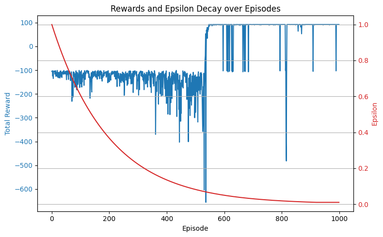

```
Testing the trained model...
Test Episode 1, Total Reward: 92
Test Episode 2, Total Reward: 92
Test Episode 3, Total Reward: 92
Test Episode 4, Total Reward: 92
Test Episode 5, Total Reward: 92

Running one episode with rendering...
Step 1: Action=0, Position=[0 0]
Step 2: Action=2, Position=[1 0]
Step 3: Action=0, Position=[1 1]
Step 4: Action=0, Position=[2 1]
Step 5: Action=0, Position=[3 1]
Step 6: Action=2, Position=[4 1]
Step 7: Action=2, Position=[4 2]
Step 8: Action=2, Position=[4 3]
Step 9: Action=2, Position=[4 4]
```

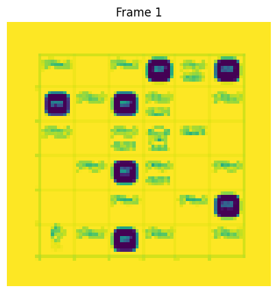

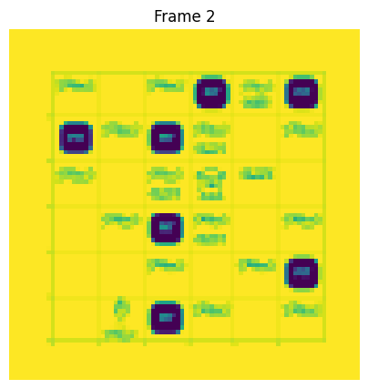

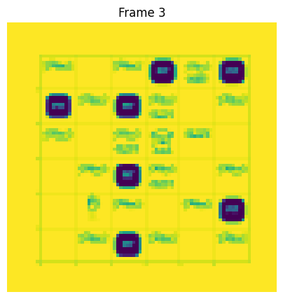

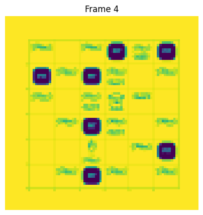

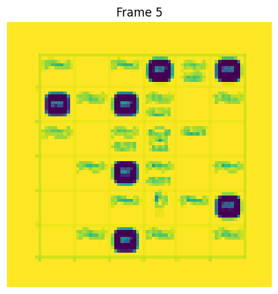

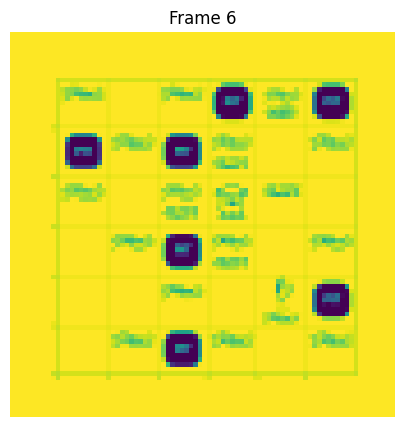

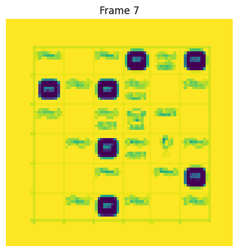

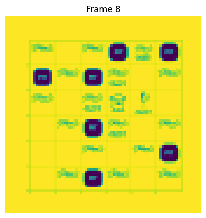

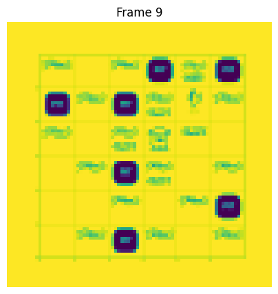

```python
import cv2
import gymnasium as gym
from gymnasium import spaces
import matplotlib.pyplot as plt
import numpy as np
import torch
import torch.nn as nn
import torch.optim as optim
import torch.nn.functional as F
from collections import deque
import random
from environment import WumpusWorldEnvironment
from time import time


# ### Q-Network Definition
class QNetwork(nn.Module):
    def __init__(self, input_size=36, hidden_size=64, output_size=4):
        """Initialize Q-Network with one hidden layer."""
        super(QNetwork, self).__init__()
        self.fc1 = nn.Linear(input_size, hidden_size)
        self.fc2 = nn.Linear(hidden_size, output_size)

    def forward(self, x):
        """Forward pass through the network."""
        x = F.relu(self.fc1(x))
        return self.fc2(x)


# ### One-Hot Encoding for State
def state_to_onehot(state, state_size=36):
    """Convert an integer state to a one-hot encoded tensor."""
    onehot_vector = np.zeros(state_size)
    onehot_vector[state] = 1
    return torch.tensor(onehot_vector, dtype=torch.float32).unsqueeze(0)


# ### Hyperparameters
gamma = 0.99               # Discount factor
epsilon_start = 1.0        # Initial epsilon for exploration
epsilon_end = 0.01         # Minimum epsilon value
epsilon_decay = 0.995      # Epsilon decay per episode
batch_size = 64            # Mini-batch size
replay_buffer_size = 10000  # Max size of the replay buffer
target_update_freq = 100   # Frequency of target network update
learning_rate = 0.001      # Learning rate
num_episodes = 1000        # Number of training episodes

# ### Initialize Environment and Networks
env = WumpusWorldEnvironment(observation_type='integer', action_type='discrete')
q_network = QNetwork()
target_network = QNetwork()
target_network.load_state_dict(q_network.state_dict())
optimizer = optim.Adam(q_network.parameters(), lr=learning_rate)
replay_buffer = deque(maxlen=replay_buffer_size)

# ### Epsilon Decay Function
def get_epsilon(episode, epsilon_start, epsilon_end, decay_rate):
    """Dynamically calculate epsilon based on decay."""
    return max(epsilon_end, epsilon_start * (decay_rate ** episode))


# ### Replay Buffer Sampling
def sample_from_replay_buffer(buffer, batch_size):
    """Sample a batch from the replay buffer."""
    transitions = random.sample(buffer, batch_size)
    states, actions, rewards, next_states, dones = zip(*transitions)
    states = torch.cat(states)
    actions = torch.tensor(actions).unsqueeze(1)
    rewards = torch.tensor(rewards, dtype=torch.float32)
    next_states = torch.cat(next_states)
    dones = torch.tensor(dones, dtype=torch.float32)
    return states, actions, rewards, next_states, dones


# ### Training Loop
def train_q_network():
    """Train the Q-network using replay buffer."""
    episode_rewards = []
    epsilon_values = []
    total_steps = 0

    print("Starting Q-learning training...")
    for episode in range(num_episodes):
        state, _ = env.reset()
        state = state_to_onehot(state)
        total_reward = 0
        done = False
        epsilon = get_epsilon(episode, epsilon_start, epsilon_end, epsilon_decay)
        epsilon_values.append(epsilon)

        while not done:
            # Choose action based on epsilon-greedy policy
            if random.random() < epsilon:
                action = env.action_space.sample()
            else:
                with torch.no_grad():
                    q_values = q_network(state)
                    action = torch.argmax(q_values).item()

            # Take the chosen action
            next_state, reward, terminated, truncated, _ = env.step(action)
            next_state = state_to_onehot(next_state)
            done = terminated or truncated
            total_reward += reward

            # Store transition in the replay buffer
            replay_buffer.append((state, action, reward, next_state, done))
            state = next_state

            # Train if enough samples are available
            if len(replay_buffer) >= batch_size:
                states, actions, rewards, next_states, dones = sample_from_replay_buffer(
                    replay_buffer, batch_size
                )

                # Compute target Q-values
                with torch.no_grad():
                    next_q_values = target_network(next_states).max(dim=1)[0]
                    targets = rewards + gamma * next_q_values * (1 - dones)

                # Compute predicted Q-values
                q_values = q_network(states).gather(1, actions).squeeze(1)
                loss = F.mse_loss(q_values, targets)

                # Backpropagation
                optimizer.zero_grad()
                loss.backward()
                optimizer.step()

            # Update target network periodically
            total_steps += 1
            if total_steps % target_update_freq == 0:
                target_network.load_state_dict(q_network.state_dict())

        episode_rewards.append(total_reward)
        print(f"Episode {episode + 1}/{num_episodes}, Reward: {total_reward}, Epsilon: {epsilon:.4f}")

    # Save trained model
    torch.save(q_network.state_dict(), "q_network_wumpus_env.pth")
    print("Training complete! Model saved as 'q_network_wumpus_env.pth'.")
    plot_results(episode_rewards, epsilon_values)


# ### Plot Results
def plot_results(episode_rewards, epsilon_values):
    """Plot rewards per episode and epsilon decay."""
    fig, ax1 = plt.subplots(figsize=(8, 5))

    color = 'tab:blue'
    ax1.plot(episode_rewards, color=color)
    ax1.set_xlabel('Episode')
    ax1.set_ylabel('Total Reward', color=color)
    ax1.tick_params(axis='y', labelcolor=color)

    ax2 = ax1.twinx()
    color = 'tab:red'
    ax2.plot(epsilon_values, color=color)
    ax2.set_ylabel('Epsilon', color=color)
    ax2.tick_params(axis='y', labelcolor=color)

    plt.title("Rewards and Epsilon Decay over Episodes")
    fig.tight_layout()
    plt.grid()
    plt.show()


# ### Test Trained Model
def test_trained_model(num_test_episodes=5):
    """Run the trained model for a few test episodes."""
    print("\nTesting the trained model...")
    q_network.load_state_dict(torch.load("q_network_wumpus_env.pth"))

    for i in range(num_test_episodes):
        state, _ = env.reset()
        state = state_to_onehot(state)
        total_reward = 0
        done = False

        while not done:
            with torch.no_grad():
                q_values = q_network(state)
                action = torch.argmax(q_values).item()

            state, reward, terminated, truncated, _ = env.step(action)
            state = state_to_onehot(state)
            total_reward += reward
            done = terminated or truncated

        print(f"Test Episode {i + 1}, Total Reward: {total_reward}")


# ### Run 1 Episode with Rendering
def run_episode_with_render():
    """Run and visualize a single episode."""
    print("\nRunning one episode with rendering...")
    state, _ = env.reset()
    state = state_to_onehot(state)
    images = []
    step_count = 0
    done = False

    while not done:
        # Render the current frame
        img = env.render(plot=False)
        images.append(img)

        # Choose the best action
        with torch.no_grad():
            q_values = q_network(state)
            action = torch.argmax(q_values).item()


        print(f"Step {step_count + 1}: Action={action}, Position={env.agent_pos}")

        # Take the action
        state, reward, terminated, truncated, _ = env.step(action)
        state = state_to_onehot(state)
        done = terminated or truncated
        step_count += 1

    # Render and display all frames
    display_frames(images)


# ### Display Episode Frames
def display_frames(images):
    """Display frames captured during an episode."""
    for i, img in enumerate(images):
        plt.figure(figsize=(5, 5))
        plt.imshow(img)
        plt.title(f"Frame {i + 1}")
        plt.axis("off")
        plt.show(block=False)
        plt.pause(0.1)
        plt.close()


# ### Main Function to Run the Pipeline
if __name__ == "__main__":
    train_q_network()
    test_trained_model()
    run_episode_with_render()
```

Cartpole DQN

```
Training CartPole-v1 with DQN...
Episode 100	Average Score: 19.80
Episode 200	Average Score: 13.81
Episode 300	Average Score: 11.72
Episode 400	Average Score: 12.19
Episode 500	Average Score: 12.82
Episode 600	Average Score: 20.27
Episode 700	Average Score: 27.23
Episode 800	Average Score: 112.05
Episode 900	Average Score: 200.28
Episode 1000	Average Score: 204.69

Training completed. Saving the agent...

Evaluating trained agent...
Episode 1	Score: 228.00
Episode 2	Score: 211.00
Episode 3	Score: 224.00
Episode 4	Score: 234.00
Episode 5	Score: 229.00
```

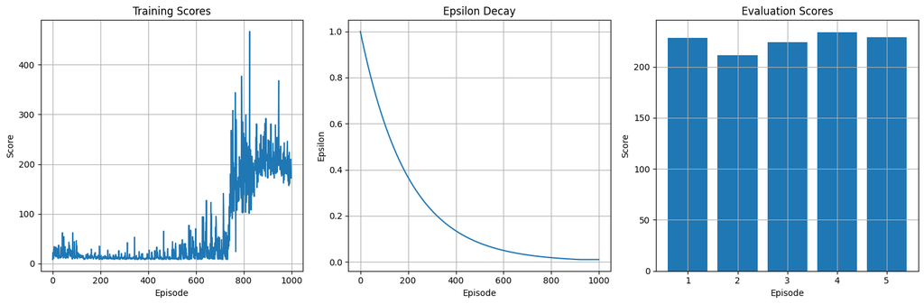

```python
import numpy as np
import torch
import torch.nn as nn
import torch.optim as optim
import gymnasium as gym
from collections import deque, namedtuple
import random
import matplotlib.pyplot as plt
from typing import List, Tuple

device = torch.device("cuda" if torch.cuda.is_available() else "cpu")

# Hyperparameters for CartPole
config = {
    'seed': 42,
    'lr': 0.001,
    'gamma': 0.99,
    'tau': 1e-3,
    'buffer_size': int(1e5),
    'batch_size': 32,
    'update_every': 5
}

# Training parameters
TRAIN_PARAMS = {
    'n_episodes': 1000,
    'max_t': 1000,
    'eps_start': 1.0,
    'eps_end': 0.01,
    'eps_decay': 0.995
}

Experience = namedtuple("Experience", field_names=["state", "action", "reward", "next_state", "done"])

class QNetwork(nn.Module):
    def __init__(self, state_size: int, action_size: int, seed: int = 42):
        super(QNetwork, self).__init__()
        self.seed = torch.manual_seed(seed)
        self.fc1 = nn.Linear(state_size, 64)
        self.fc2 = nn.Linear(64, 64)
        self.fc3 = nn.Linear(64, action_size)

    def forward(self, state):
        x = torch.relu(self.fc1(state))
        x = torch.relu(self.fc2(x))
        return self.fc3(x)

class ReplayBuffer:
    def __init__(self, buffer_size: int, batch_size: int, seed: int = 42):
        self.memory = deque(maxlen=buffer_size)
        self.batch_size = batch_size
        self.seed = random.seed(seed)

    def add(self, state, action, reward, next_state, done):
        e = Experience(state, action, reward, next_state, done)
        self.memory.append(e)

    def sample(self):
        experiences = random.sample(self.memory, k=self.batch_size)

        states = torch.from_numpy(np.vstack([e.state for e in experiences if e is not None])).float().to(device)
        actions = torch.from_numpy(np.vstack([e.action for e in experiences if e is not None])).long().to(device)
        rewards = torch.from_numpy(np.vstack([e.reward for e in experiences if e is not None])).float().to(device)
        next_states = torch.from_numpy(np.vstack([e.next_state for e in experiences if e is not None])).float().to(device)
        dones = torch.from_numpy(np.vstack([int(e.done) for e in experiences if e is not None])).float().to(device)

        return (states, actions, rewards, next_states, dones)

    def __len__(self):
        return len(self.memory)

class DQNAgent:
    def __init__(self, state_size: int, action_size: int, config: dict):
        self.state_size = state_size
        self.action_size = action_size
        self.seed = random.seed(config['seed'])

        self.qnetwork_local = QNetwork(state_size, action_size, config['seed']).to(device)
        self.qnetwork_target = QNetwork(state_size, action_size, config['seed']).to(device)
        self.optimizer = optim.Adam(self.qnetwork_local.parameters(), lr=config['lr'])

        self.memory = ReplayBuffer(config['buffer_size'], config['batch_size'], config['seed'])

        self.t_step = 0
        self.gamma = config['gamma']
        self.tau = config['tau']
        self.update_every = config['update_every']
        self.batch_size = config['batch_size']

    def step(self, state, action, reward, next_state, done):
        self.memory.add(state, action, reward, next_state, done)
        self.t_step = (self.t_step + 1) % self.update_every
        if self.t_step == 0:
            if len(self.memory) > self.batch_size:
                experiences = self.memory.sample()
                self.learn(experiences)

    def act(self, state, eps: float = 0.):
        if isinstance(state, tuple):
            state = state[0]
        state = torch.from_numpy(state).float().unsqueeze(0).to(device)
        self.qnetwork_local.eval()
        with torch.no_grad():
            action_values = self.qnetwork_local(state)
        self.qnetwork_local.train()

        if random.random() > eps:
            return np.argmax(action_values.cpu().data.numpy())
        else:
            return random.choice(np.arange(self.action_size))

    def learn(self, experiences: Tuple):
        states, actions, rewards, next_states, dones = experiences
        Q_targets_next = self.qnetwork_target(next_states).detach().max(1)[0].unsqueeze(1)
        Q_targets = rewards + (self.gamma * Q_targets_next * (1 - dones))
        Q_expected = self.qnetwork_local(states).gather(1, actions)
        loss = nn.MSELoss()(Q_expected, Q_targets)
        self.optimizer.zero_grad()
        loss.backward()
        self.optimizer.step()
        self.soft_update(self.qnetwork_local, self.qnetwork_target, self.tau)

    def soft_update(self, local_model, target_model, tau: float):
        for target_param, local_param in zip(target_model.parameters(), local_model.parameters()):
            target_param.data.copy_(tau * local_param.data + (1.0 - tau) * target_param.data)

def train_dqn(env, agent: DQNAgent, train_params: dict):
    scores = []
    scores_window = deque(maxlen=100)
    eps_history = []
    eps = train_params['eps_start']

    for i_episode in range(1, train_params['n_episodes'] + 1):
        state = env.reset()
        if isinstance(state, tuple):
            state = state[0]
        score = 0
        for t in range(train_params['max_t']):
            action = agent.act(state, eps)
            next_state, reward, done, truncated, info = env.step(action)
            done = done or truncated
            agent.step(state, action, reward, next_state, done)
            state = next_state
            score += reward
            if done:
                break

        scores_window.append(score)
        scores.append(score)
        eps_history.append(eps)
        eps = max(train_params['eps_end'], train_params['eps_decay'] * eps)

        print('\rEpisode {}\tAverage Score: {:.2f}'.format(i_episode, np.mean(scores_window)), end="")
        if i_episode % 100 == 0:
            print('\rEpisode {}\tAverage Score: {:.2f}'.format(i_episode, np.mean(scores_window)))

    # Save the agent after all episodes
    print('\nTraining completed. Saving the agent...')
    torch.save({
        'qnetwork_local': agent.qnetwork_local.state_dict(),
        'qnetwork_target': agent.qnetwork_target.state_dict(),
        'optimizer': agent.optimizer.state_dict(),
    }, 'cartpole_dqn_agent.pth')

    return scores, eps_history

def evaluate(env, agent: DQNAgent, n_episodes: int = 5, max_t: int = 1000, render: bool = False):
    scores = []
    for i_episode in range(1, n_episodes + 1):
        state = env.reset()
        if isinstance(state, tuple):
            state = state[0]
        score = 0
        for t in range(max_t):
            if render:
                env.render()
            action = agent.act(state, eps=0)
            next_state, reward, done, truncated, info = env.step(action)
            done = done or truncated
            state = next_state
            score += reward
            if done:
                break
        scores.append(score)
        print(f'Episode {i_episode}\tScore: {score:.2f}')
    return scores

def plot_results(scores: List[float], eps_history: List[float], eval_scores: List[float]):
    # Plot training scores
    plt.figure(figsize=(15, 5))
    plt.subplot(1, 3, 1)
    plt.plot(scores)
    plt.title("Training Scores")
    plt.xlabel('Episode')
    plt.ylabel('Score')
    plt.grid(True)

    # Plot epsilon decay
    plt.subplot(1, 3, 2)
    plt.plot(eps_history)
    plt.title("Epsilon Decay")
    plt.xlabel('Episode')
    plt.ylabel('Epsilon')
    plt.grid(True)

    # Plot evaluation scores
    plt.subplot(1, 3, 3)
    plt.bar(range(1, len(eval_scores) + 1), eval_scores)
    plt.title("Evaluation Scores")
    plt.xlabel('Episode')
    plt.ylabel('Score')
    plt.xticks(range(1, len(eval_scores) + 1))
    plt.grid(True)

    plt.tight_layout()
    plt.show()

def main():
    print("Training CartPole-v1 with DQN...")
    env = gym.make('CartPole-v1')
    state_size = env.observation_space.shape[0]
    action_size = env.action_space.n

    agent = DQNAgent(state_size, action_size, config)
    scores, eps_history = train_dqn(env, agent, TRAIN_PARAMS)

    # Evaluation
    print("\nEvaluating trained agent...")
    eval_scores = evaluate(env, agent, n_episodes=5, render=False)

    # Plot results
    plot_results(scores, eps_history, eval_scores)
    env.close()

if __name__ == "__main__":
    main()
```

LunarLander DQN

```
Training LunarLander-v3 with DQN
Episode 1/1000 | Score: -125.37005213096445 | Avg: -125.37 | Epsilon: 0.9950
Episode 2/1000 | Score: -85.85822571078157 | Avg: -105.61 | Epsilon: 0.9900
Episode 3/1000 | Score: -16.245885873767023 | Avg: -75.82 | Epsilon: 0.9851
Episode 4/1000 | Score: -216.81508061963225 | Avg: -111.07 | Epsilon: 0.9801
Episode 5/1000 | Score: -130.53147991572075 | Avg: -114.96 | Epsilon: 0.9752
Episode 6/1000 | Score: -92.72446112676852 | Avg: -111.26 | Epsilon: 0.9704
Episode 7/1000 | Score: -105.1066397528256 | Avg: -110.38 | Epsilon: 0.9655
Episode 8/1000 | Score: -186.50005694925665 | Avg: -119.89 | Epsilon: 0.9607
Episode 9/1000 | Score: -238.9833610946387 | Avg: -133.13 | Epsilon: 0.9559
Episode 10/1000 | Score: -363.1851535623878 | Avg: -156.13 | Epsilon: 0.9511
Episode 11/1000 | Score: -112.36265221283786 | Avg: -152.15 | Epsilon: 0.9464
Episode 12/1000 | Score: -299.7635669042122 | Avg: -164.45 | Epsilon: 0.9416
Episode 13/1000 | Score: -104.14965366754723 | Avg: -159.82 | Epsilon: 0.9369
Episode 14/1000 | Score: -214.41183657265893 | Avg: -163.71 | Epsilon: 0.9322
Episode 15/1000 | Score: -131.7625739075118 | Avg: -161.58 | Epsilon: 0.9276
Episode 16/1000 | Score: -114.35561393955625 | Avg: -158.63 | Epsilon: 0.9229
Episode 17/1000 | Score: -108.34839700149433 | Avg: -155.67 | Epsilon: 0.9183
Episode 18/1000 | Score: -314.62205971020535 | Avg: -164.51 | Epsilon: 0.9137
Episode 19/1000 | Score: -84.85438006457738 | Avg: -160.31 | Epsilon: 0.9092
Episode 20/1000 | Score: -53.4249854980984 | Avg: -154.97 | Epsilon: 0.9046
Episode 21/1000 | Score: -300.7764745176576 | Avg: -161.91 | Epsilon: 0.9001
Episode 22/1000 | Score: -303.6512318834583 | Avg: -168.35 | Epsilon: 0.8956
Episode 23/1000 | Score: -320.0490038919979 | Avg: -174.95 | Epsilon: 0.8911
Episode 24/1000 | Score: -420.55747773443284 | Avg: -185.18 | Epsilon: 0.8867
Episode 25/1000 | Score: -121.9134084085778 | Avg: -182.65 | Epsilon: 0.8822
Episode 26/1000 | Score: -266.59217049042013 | Avg: -185.88 | Epsilon: 0.8778
Episode 27/1000 | Score: -167.4949409782685 | Avg: -185.20 | Epsilon: 0.8734
Episode 28/1000 | Score: -311.8706816390659 | Avg: -189.72 | Epsilon: 0.8691
Episode 29/1000 | Score: -164.49315020846524 | Avg: -188.85 | Epsilon: 0.8647
Episode 30/1000 | Score: -211.9121192721986 | Avg: -189.62 | Epsilon: 0.8604
Episode 31/1000 | Score: -188.4401008124197 | Avg: -189.58 | Epsilon: 0.8561
Episode 32/1000 | Score: -96.15119905619615 | Avg: -186.66 | Epsilon: 0.8518
Episode 33/1000 | Score: -166.81803915647419 | Avg: -186.06 | Epsilon: 0.8475
Episode 34/1000 | Score: -111.91380029074435 | Avg: -183.88 | Epsilon: 0.8433
Episode 35/1000 | Score: -225.9469484161415 | Avg: -185.08 | Epsilon: 0.8391
Episode 36/1000 | Score: -588.3071907339263 | Avg: -196.29 | Epsilon: 0.8349
Episode 37/1000 | Score: -214.80652286872834 | Avg: -196.79 | Epsilon: 0.8307
Episode 38/1000 | Score: -329.1740849888534 | Avg: -200.27 | Epsilon: 0.8266
Episode 39/1000 | Score: -74.27946914361877 | Avg: -197.04 | Epsilon: 0.8224
```

[output cut: 397 more lines]

```
Episode 437/1000 | Score: 107.76902988226904 | Avg: 91.59 | Epsilon: 0.1119
Episode 438/1000 | Score: 110.07861758111247 | Avg: 91.76 | Epsilon: 0.1113
Episode 439/1000 | Score: 236.37487189831347 | Avg: 93.08 | Epsilon: 0.1107
Episode 440/1000 | Score: 230.141827030442 | Avg: 94.82 | Epsilon: 0.1102
Episode 441/1000 | Score: 81.83279317145637 | Avg: 94.73 | Epsilon: 0.1096
Episode 442/1000 | Score: 247.6148294641727 | Avg: 96.45 | Epsilon: 0.1091
Episode 443/1000 | Score: 210.5694066952434 | Avg: 97.50 | Epsilon: 0.1085
Episode 444/1000 | Score: 107.13304350075113 | Avg: 97.93 | Epsilon: 0.1080
Episode 445/1000 | Score: 112.30710927493274 | Avg: 98.60 | Epsilon: 0.1075
Episode 446/1000 | Score: 139.96798069682814 | Avg: 99.29 | Epsilon: 0.1069
Episode 447/1000 | Score: 119.26598667591868 | Avg: 99.72 | Epsilon: 0.1064
Environment solved in 448 episodes! Average score: 101.09
Model saved as 'dqn_lunarlander.pth'

Evaluating trained agent...
```

```
Average evaluation score: 183.21
```

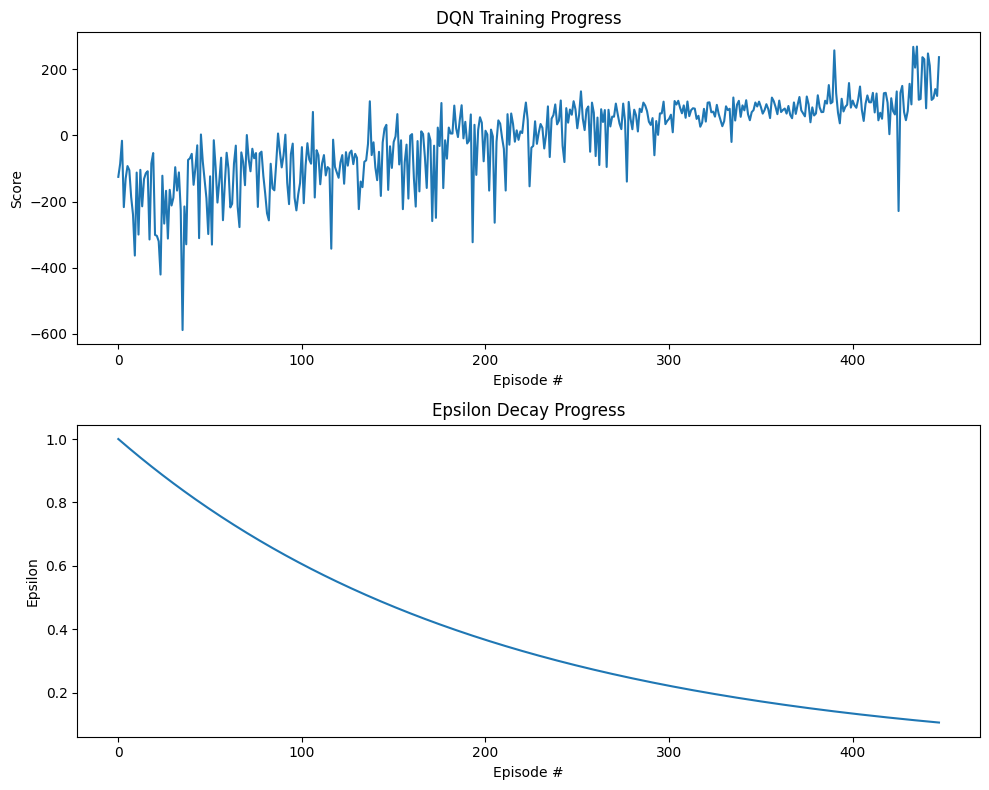

```python
import numpy as np
import torch
import torch.nn as nn
import torch.optim as optim
import gymnasium as gym
from collections import deque, namedtuple
import random
import matplotlib.pyplot as plt
from typing import List, Tuple

# Device configuration
device = torch.device("mps" if torch.backends.mps.is_available() else "cuda" if torch.cuda.is_available() else "cpu")

# Hyperparameters for LunarLander
config = {
    'seed': 42,
    'lr': 0.0005,
    'gamma': 0.99,
    'tau': 1e-3,
    'buffer_size': int(1e5),
    'batch_size': 64,
    'update_every': 4,
    'early_stop_score': 100.0  # Average score to stop training
}

# Training parameters
TRAIN_PARAMS = {
    'n_episodes': 1000,
    'max_t': 500,
    'eps_start': 1.0,
    'eps_end': 0.01,
    'eps_decay': 0.995
}

Experience = namedtuple("Experience", field_names=["state", "action", "reward", "next_state", "done"])

class QNetwork(nn.Module):
    def __init__(self, state_size: int, action_size: int, seed: int = 42):
        super(QNetwork, self).__init__()
        self.seed = torch.manual_seed(seed)
        self.fc1 = nn.Linear(state_size, 128)
        self.fc2 = nn.Linear(128, 64)
        self.fc3 = nn.Linear(64, action_size)

    def forward(self, state):
        x = torch.relu(self.fc1(state))
        x = torch.relu(self.fc2(x))
        return self.fc3(x)

class ReplayBuffer:
    def __init__(self, buffer_size: int, batch_size: int, seed: int = 42):
        self.memory = deque(maxlen=buffer_size)
        self.batch_size = batch_size
        self.seed = random.seed(seed)

    def add(self, state, action, reward, next_state, done):
        e = Experience(state, action, reward, next_state, done)
        self.memory.append(e)

    def sample(self):
        experiences = random.sample(self.memory, k=self.batch_size)

        states = torch.from_numpy(np.vstack([e.state for e in experiences if e is not None])).float().to(device)
        actions = torch.from_numpy(np.vstack([e.action for e in experiences if e is not None])).long().to(device)
        rewards = torch.from_numpy(np.vstack([e.reward for e in experiences if e is not None])).float().to(device)
        next_states = torch.from_numpy(np.vstack([e.next_state for e in experiences if e is not None])).float().to(device)
        dones = torch.from_numpy(np.vstack([int(e.done) for e in experiences if e is not None])).float().to(device)

        return (states, actions, rewards, next_states, dones)

    def __len__(self):
        return len(self.memory)

def train_dqn(env, state_size, action_size, config, train_params):
    qnetwork_local = QNetwork(state_size, action_size, config['seed']).to(device)
    qnetwork_target = QNetwork(state_size, action_size, config['seed']).to(device)
    optimizer = optim.Adam(qnetwork_local.parameters(), lr=config['lr'])

    memory = ReplayBuffer(config['buffer_size'], config['batch_size'], config['seed'])
    t_step = 0

    scores = []
    eps_history = []
    eps = train_params['eps_start']
    eps_decay = train_params['eps_decay']
    eps_end = train_params['eps_end']

    for i_episode in range(1, train_params['n_episodes'] + 1):
        state, _ = env.reset()
        score = 0
        for t in range(train_params['max_t']):
            state_tensor = torch.from_numpy(state).float().unsqueeze(0).to(device)
            qnetwork_local.eval()
            with torch.no_grad():
                action_values = qnetwork_local(state_tensor)
            qnetwork_local.train()

            if random.random() > eps:
                action = np.argmax(action_values.cpu().data.numpy())
            else:
                action = random.choice(np.arange(action_size))

            next_state, reward, done, _, _ = env.step(action)
            memory.add(state, action, reward, next_state, done)

            if len(memory) > config['batch_size']:
                experiences = memory.sample()
                states, actions, rewards, next_states, dones = experiences

                Q_targets_next = qnetwork_target(next_states).detach().max(1)[0].unsqueeze(1)
                Q_targets = rewards + (config['gamma'] * Q_targets_next * (1 - dones))
                Q_expected = qnetwork_local(states).gather(1, actions)

                loss = nn.MSELoss()(Q_expected, Q_targets)
                optimizer.zero_grad()
                loss.backward()
                optimizer.step()

                # Soft update
                for target_param, local_param in zip(qnetwork_target.parameters(), qnetwork_local.parameters()):
                    target_param.data.copy_(config['tau'] * local_param.data + (1.0 - config['tau']) * target_param.data)

            state = next_state
            score += reward
            if done:
                break

        scores.append(score)
        eps_history.append(eps)
        eps = max(eps_end, eps_decay * eps)

        if i_episode >= 100:
            recent_avg_score = np.mean(scores[-100:])
            if recent_avg_score >= config['early_stop_score']:
                print(f"Environment solved in {i_episode} episodes! Average score: {recent_avg_score:.2f}")
                break

        print(f"Episode {i_episode}/{train_params['n_episodes']} | Score: {score} | Avg: {np.mean(scores[-100:]):.2f} | Epsilon: {eps:.4f}")

    torch.save(qnetwork_local.state_dict(), 'dqn_lunarlander.pth')
    print("Model saved as 'dqn_lunarlander.pth'")

    return scores, eps_history

def evaluate(env, state_size, action_size, render=False):
    qnetwork_local = QNetwork(state_size, action_size).to(device)
    qnetwork_local.load_state_dict(torch.load('dqn_lunarlander.pth'))
    qnetwork_local.eval()

    scores = []
    for i in range(5):
        state, _ = env.reset()
        score = 0
        for t in range(1000):
            state_tensor = torch.from_numpy(state).float().unsqueeze(0).to(device)
            with torch.no_grad():
                action_values = qnetwork_local(state_tensor)
            action = np.argmax(action_values.cpu().data.numpy())

            next_state, reward, done, _, _ = env.step(action)
            state = next_state
            score += reward
            if render:
                env.render()
            if done:
                break
        scores.append(score)
    print(f"Average evaluation score: {np.mean(scores):.2f}")
    return scores

def plot_results(scores, eps_history):
    fig, axs = plt.subplots(2, 1, figsize=(10, 8))
    axs[0].plot(np.arange(len(scores)), scores)
    axs[0].set_ylabel('Score')
    axs[0].set_xlabel('Episode #')
    axs[0].set_title('DQN Training Progress')

    axs[1].plot(np.arange(len(eps_history)), eps_history)
    axs[1].set_ylabel('Epsilon')
    axs[1].set_xlabel('Episode #')
    axs[1].set_title('Epsilon Decay Progress')

    plt.tight_layout()
    plt.show()

def main():
    print("Training LunarLander-v3 with DQN")
    env = gym.make("LunarLander-v3")
    state_size = env.observation_space.shape[0]
    action_size = env.action_space.n

    scores, eps_history = train_dqn(env, state_size, action_size, config, TRAIN_PARAMS)

    print("\nEvaluating trained agent...")
    evaluate(env, state_size, action_size, render=True)

    plot_results(scores, eps_history)
    env.close()

if __name__ == "__main__":
    main()
```